# Final R Reference

### boxplot() and par()

#### boxplot():

This function allows us to create a box plot of our data. By istelf it is useful, but boxplot usually don’t tell us too much by themselves, but accompanied by others they can be incredibly insightful.

#### par():

In order to make box plots more insightful, we use par to create a panel in our plot that allows for more than one graph. In order to do that, we use the mfrow= parameter which allows for us to divide a panel however we want, with the first number in our c() being the one for the rows and the second one for the number of columns.

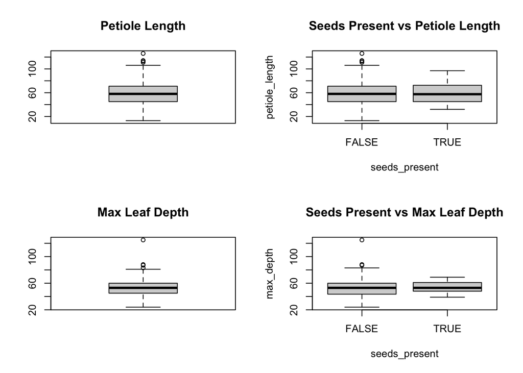

```r
par(mfrow = c(2, 2))
#Creating a normal box plot of the petiole length
boxplot(ginkgo$petiole_length, main="Petiole Length")
#Conditional box plot separates our numeric column data into classes according to a given value. In this case we are separating the petiole length depending on whether there are seeds present or not.
boxplot(petiole_length~seeds_present, data=ginkgo, main="Seeds Present vs Petiole Length")
#Creating another box plot of the max_depth of the leafs
boxplot(ginkgo$max_depth, main="Max Leaf Depth")
#Similar to the above conditional box plot, here we are creating a conditional box plot with the usage of max_depth column as opposed to the seeds_present
boxplot(max_depth~seeds_present, data=ginkgo, main="Seeds Present vs Max Leaf Depth")
```

## Distribution Funcitons

#### In the case of normal distirbution funcitons:

The parameters of mean and sd fall under the same descriptions as the functions described above. If mean or sd are not given then it is assumed the default values of 0 and 1, respectively.

#### In the case of the binomial funcitons:

The most important parameters are size and prob. Size is the number of trials. If size is not an integer, it will return a null value. The prob parameter accepts the probability of success of each trial.

### dnorm()

This is the density for the normal distribution. Its first value has to be in vector of quantiles.

```r
#Creatug=ng density values for all of the entries
dnorm(ginkgo$max_depth, mean=mean(ginkgo$max_depth), sd=sd(ginkgo$max_depth))
```

```
##   [1] 2.814596e-02 3.126438e-02 2.143551e-02 2.892980e-02 3.043009e-02
##   [6] 2.683271e-02 2.705497e-02 2.705497e-02 3.053785e-02 3.126438e-02
##  [11] 2.705497e-02 1.983678e-03 2.143551e-02 3.126438e-02 2.143551e-02
##  [16] 3.134254e-02 2.976217e-02 3.053785e-02 1.271789e-02 3.134254e-02
##  [21] 1.551354e-02 1.017176e-02 4.487465e-03 1.271789e-02 1.408975e-02
##  [26] 9.012919e-03 1.140896e-02 1.017176e-02 2.428067e-02 2.143551e-02
##  [31] 1.408975e-02 1.140896e-02 2.794765e-02 1.846222e-02 1.846222e-02
##  [36] 1.551354e-02 3.043009e-02 3.099449e-02 1.725849e-02 1.140896e-02
##  [41] 3.092153e-02 3.122756e-02 2.683271e-02 3.126438e-02 3.043009e-02
##  [46] 2.794765e-02 2.171518e-02 2.560371e-02 1.435793e-02 2.683271e-02
##  [51] 1.408975e-02 2.683271e-02 3.126438e-02 2.428067e-02 2.683271e-02
##  [56] 3.251547e-03 2.794765e-02 1.697610e-02 2.814596e-02 2.705497e-02
##  [61] 3.053785e-02 3.099449e-02 2.976217e-02 3.099449e-02 3.043009e-02
##  [66] 2.143551e-02 3.122756e-02 3.092153e-02 2.705497e-02 2.023907e-02
##  [71] 3.053785e-02 2.683271e-02 1.846222e-02 2.428067e-02 1.846222e-02
```

[output cut: 29 more lines]

### pnorm()

This is equal to the distribution function. Its first value has to be in vector of quantiles.

```r
#Creating distribution values for all of the entries
pnorm(ginkgo$max_depth, mean=mean(ginkgo$max_depth), sd=sd(ginkgo$max_depth))
```

```
##   [1] 0.67863973 0.52832771 0.19167812 0.34445633 0.40392583 0.28860531
##   [7] 0.70625080 0.70625080 0.59025440 0.52832771 0.70625080 0.99060043
##  [13] 0.19167812 0.52832771 0.19167812 0.49700816 0.37381545 0.59025440
##  [19] 0.08961544 0.49700816 0.11781228 0.06677359 0.02432436 0.08961544
##  [25] 0.10301444 0.05718800 0.07755766 0.06677359 0.23742924 0.19167812
##  [31] 0.10301444 0.07755766 0.31600580 0.15177235 0.15177235 0.11781228
##  [37] 0.40392583 0.55947296 0.86267770 0.07755766 0.43461676 0.46570704
##  [43] 0.28860531 0.52832771 0.40392583 0.31600580 0.80420294 0.26237842
##  [49] 0.89427013 0.28860531 0.10301444 0.28860531 0.52832771 0.23742924
##  [55] 0.28860531 0.01663582 0.31600580 0.13405447 0.67863973 0.70625080
##  [61] 0.59025440 0.55947296 0.37381545 0.55947296 0.40392583 0.19167812
##  [67] 0.46570704 0.43461676 0.70625080 0.82518219 0.59025440 0.28860531
##  [73] 0.15177235 0.23742924 0.15177235 0.46570704 0.65000430 0.46570704
##  [79] 0.73271040 0.99613631 0.62048916 0.67863973 0.04872010 0.65000430
##  [85] 0.67863973 0.19167812 0.55947296 0.40392583 0.43461676 0.70625080
```

[output cut: 22 more lines]

### qnorm()

This is equal to the quantile function. Its first value has to be a vector of probabilities.

```r
#Getting the quantile value for 0.5
qnorm(0.5, mean=mean(ginkgo$max_depth), sd=sd(ginkgo$max_depth))
```

```
## [1] 53.09545
```

### dbinom()

Density function for the binomial distribution.

```r
#Probability of 10 trials being successful when we have a the success trial is 0.6 and we do it 12 times
dbinom(x=10, size=12, prob=0.6)
```

```
## [1] 0.06385228
```

### pbinom()

Distribution function for the binomial distribution.

```r
#The probability of 4 or fewer successes during 10 trials where the probability of success on each trial is 0.5
pbinom(4, size=10, prob=.5)
```

```
## [1] 0.3769531
```

### qbinom()

Quantile function for the binomial distribution.

```r
#The 10th quantile of a binomial distribution with 10 trials and prob of success on each trial = 0.5
qbinom(.10, size=10, prob=.5)
```

```
## [1] 3
```